# Variant Calling

### 1.1.4 SRR445717 – Quality Control Plots

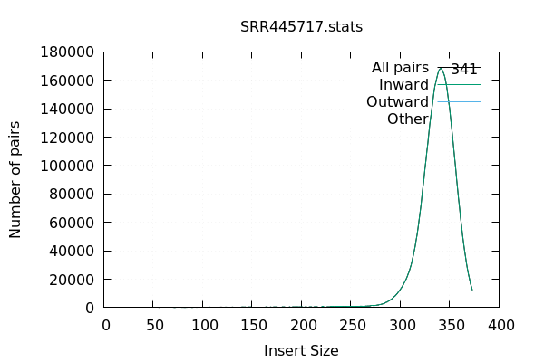

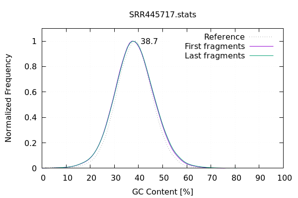

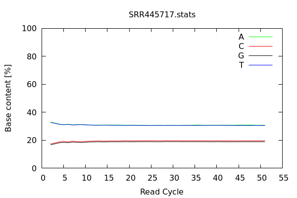

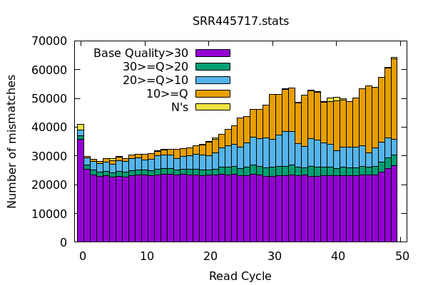

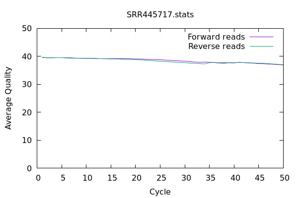

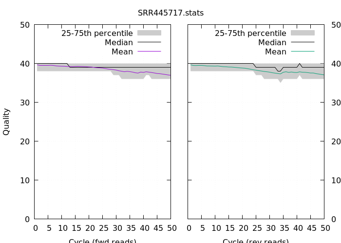

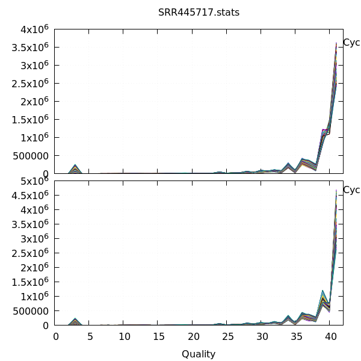

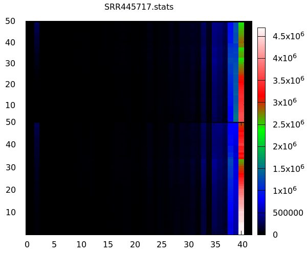

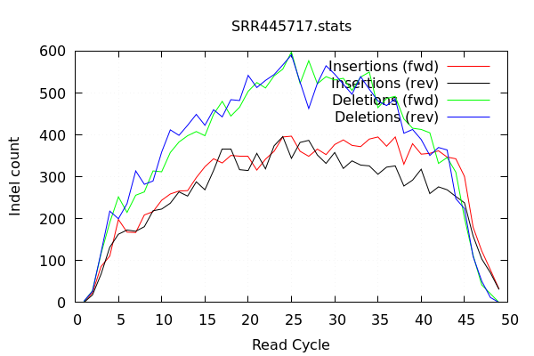

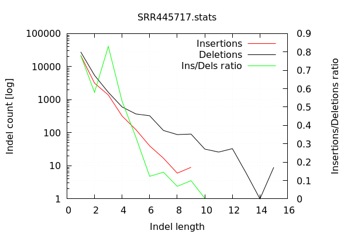

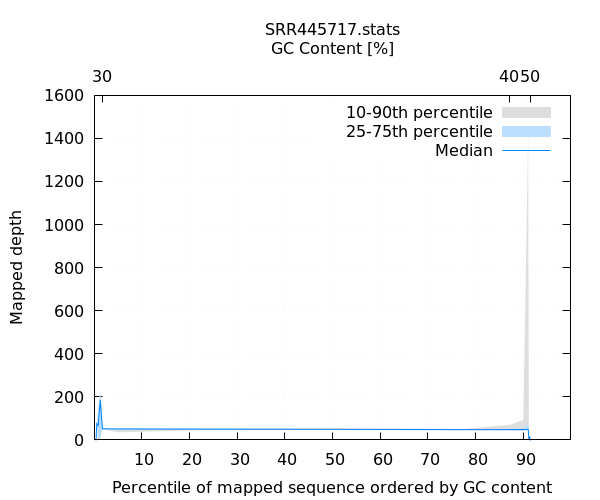

## 1.2 Generating a pileup

```
samtools mpileup  -f /mnt/atgc-d1/bioinfoII/drobles/variant_calling/data/S288C_ref.fa /mnt/atgc-d1/bioinfoII/drobles/variant_calling/data/SRR445715.aligned.sorted.bam | less -S
```

**What is the read depth at position chrI:29519? What is the reference base? Are there any non-reference bases?**

```
chrI    29519   A       56      ,$,,.,.,..,,,,..,..,……….,.,,.,,……..,……….,       BCB=A4BB9>BB@?A>B>B?BBBA@A?CB7?C8AB=@BBBCB=B@@@BBCAC?B00
```

Read depth: 56

Reference base: A

Non-reference bases: None detected (all reads appear to match the reference)

**What about at position chrI:29522? What is the reference base? Are there any non-reference bases?**

```
chrI    29522   T       46      aaaaAaAAaAAAAAAAAAAaAaaAaaAAAAAAAAaAAAAAAAAAAa  8;??>:4BB@BABB;A=BABBCBBB?ABA=CABBBAAABC5CAB00
```

Read depth: 46

Reference base: T

Non-reference bases: A (possible T -> A substitution)

## 1.3 Generating genotype likelihoods and variant calling

The bcftools mpileup command can be used to generate genotype likelihoods. Try running the following command:

```
module load bcftools/1.10.2 bcftools mpileup -f
/mnt/atgc-d1/bioinfoII/drobles/variant_calling/data/S288C_ref.fa\
/mnt/atgc-d1/bioinfoII/drobles/variant_calling/data/SRR445715.aligned.sorted.bam
\| less -S
```

This is an intermediate output that contains genotype likelihoods, as well as other raw information necessary to perform variant calling. However, we usually don’t see this information as it is streamed directly into the variant caller:

```
bcftools mpileup -f
/mnt/atgc-d1/bioinfoII/drobles/variant_calling/data/S288C_ref.fa\
/mnt/atgc-d1/bioinfoII/drobles/variant_calling/data/SRR445715.aligned.sorted.bam
\|\
bcftools call -m --ploidy 1 \| less -S
```

**Why did we use these settings? What settings would you use for human data?**

We used the –ploidy 1 option because Saccharomyces cerevisiae is haploid, meaning each genomic position typically has only one allele. The -m flag enables the multiallelic caller in bcftools call, which is appropriate for identifying both SNPs and indels. These settings ensure appropriate genotype likelihood calculations and accurate variant calling for haploid organisms.

For human data, which is diploid, we would replace –ploidy 1 with –ploidy 2. Additionally, we would typically use quality filters (e.g., -q for base quality), consider calling variants across multiple samples (-g or -G flags), and output compressed files (e.g., using –output-type z for .vcf.gz) to handle the larger genome and file sizes efficiently. The INFO and FORMAT fields of each entry tells us something about the data at the position in the genome. It consists of a set of key-value pairs with the tags being explained in the header of the VCF file (see the ##INFO and ##FORMAT lines in the header).

**What option should we add to only print variant sites?**

To print only variant sites, we should include the -v option in the bcftools call command. This filters out reference-matching positions and outputs only positions where variants were called.

Let mpileup output more information. For example we can ask it to add the FORMAT/AD tag which informs about the number of high-quality reads that support alleles listed in REF and ALT columns. The list of all available tags can be printed with “bcftools mpileup -a?”.

Now let’s run the variant calling again, this time adding the -a AD option. We will also add the -Ou option to mpileup so that it streams a binary uncompressed BCF into call. This is to avoid the unnecessary CPU overhead of formatting the internal binary format into plain text VCF only to be immediately formatted back to the internal binary format again:

```
bcftools mpileup -a AD -f /mnt/atgc-d1/bioinfoII/drobles/variant_calling/data/S288C_ref.fa \
/mnt/atgc-d1/bioinfoII/drobles/variant_calling/data/SRR445715.aligned.sorted.bam -Ou | \
bcftools call -mv --ploidy 1 -o SRR445715.vcf

bcftools mpileup -a AD -f /mnt/atgc-d1/bioinfoII/drobles/variant_calling/data/S288C_ref.fa \
/mnt/atgc-d1/bioinfoII/drobles/variant_calling/data/SRR445716.aligned.sorted.bam -Ou | \
bcftools call -mv --ploidy 1 -o SRR445716.vcf

bcftools mpileup -a AD -f /mnt/atgc-d1/bioinfoII/drobles/variant_calling/data/S288C_ref.fa \
/mnt/atgc-d1/bioinfoII/drobles/variant_calling/data/SRR445717.aligned.sorted.bam -Ou | \
bcftools call -mv --ploidy 1 -o SRR445717.vcf
```

Now examine the VCF file output of file SRR445717.vc fusing the UNIX command less:

`less -S SRR445717.vcf`

comand to use for a specific position:

`grep -P '^chrIV\t122724' SRR445717.vcf`

```
chrIV 122724 . G A 225 .
DP=58;VDB=0.0205157;SGB=-0.693147;MQSB=1;MQ0F=0;AC=1;AN=1;DP4=0,0,27,26;MQ=60
GT:PL:AD 1:255,0:0,53
```

**What is the reference and variant base at position chrIV:122724?**

Reference base: G

Variant base: A

**What is the total read depth at position chrIV:122724?**

Total read depth = 58 reads

**What is the number of high-quality forward reads supporting the variant call at position chrIV:122724? How many reads support the reference allele?**

At position chrIV:122724, there are 27 high-quality forward reads supporting the variant allele (A). There are 0 reads supporting the reference allele (G).

**What sort of event is happening at position chrI:29007?**

`grep -P '^chrI\t29007' SRR445717.vcf`

```
chrI 29007 . T TG 122 .
INDEL;IDV=23;IMF=0.958333;DP=24;VDB=0.0158681;SGB=-0.636426;MQSB=0.882497;MQ0F=0;AC=1;AN=1;DP4=4,13,2,5;MQ=35
GT:PL:AD 1:149,0:17,7
```

At position chrI:29007, the reference base is T and the alternate allele is TG, indicating an insertion of the base G following the reference base. Therefore, this is an insertion event.

## 1.4 Variant filtering

In the series of commands we will learn how to filter and extract information from VCFs. Most of the bcftools commands accept the -i, –include and -e, –exclude options which will come handy when filtering using fixed thresholds (you can look at the bcftools documentation here: http://www.htslib.org/doc/bcftools.html). We will estimate the quality of the callset by calculating the transition/transversion ratio.

In order to verify that the filtering expression has the desired effect, it is useful to first run a few small tests. Let’s start with printing a simple list of positions from the VCF using the bcftools query command (manual) and pipe through the head command to trim the output after a few lines:

`bcftools query -f'POS = %POS\n' SRR445715.vcf | head`

```
POS = 83
POS = 136
POS = 262
POS = 286
POS = 305
POS = 476
POS = 485
POS = 610
POS = 633
POS = 654
```

The formatting expression “POS = %POS” was expanded for each line in the VCF and consisted of the string “POS =”, which was printed on the output unchanged, the string with a special meaning “%POS”, which was replaced by the POS column for each line, and the new line character “”, which put the new line character after each VCF record. (If it were not present, the positions from the entire VCF would be printed on a single line.)

Now add REF and ALT allele to the output, separated by a comma

`bcftools query -f'%POS %REF,%ALT\n' SRR445715.vcf | head`

```
83 AG,A
136 G,A
262 A,G
286 A,T
305 C,G
476 G,T
485 T,C
610 G,A
633 T,C
654 C,T
```

In the next step add also the quality, genotype and sequencing depth to the output. For the depth, check the AD annotation, which gives the number of reads observed for each reference and alternate alleles. For example, if there were 3 reads with the reference allele and 5 reads with the alternate allele, the AD field would be AD=3,5. Note that the FORMAT fields must be enclosed within square brackets “[]” to iterate over all samples in the VCF.

To illustrate this, first let’s make a combined VCF:

```
module load htslib/1.9
bgzip SRR445715.vcf
bgzip SRR445716.vcf
bgzip SRR445717.vcf
bcftools index SRR445715.vcf.gz
bcftools index SRR445716.vcf.gz
bcftools index SRR445717.vcf.gz
bcftools merge -0 -o combined.vcf SRR445715.vcf.gz SRR445716.vcf.gz SRR445717.vcf.gz
```

```
bcftools query -f'%POS %QUAL [%GT %AD  ] %REF %ALT\n' combined.vcf | head
```

Now filter rows with quality smaller than 30 and exclude indels. Check the record at positions 83, 244, 262, 509, 546, are they still present in the output?

`bcftools query -f'%POS %QUAL [%GT %AD ] %REF %ALT\n' -i'QUAL>=30 && type="snp"' combined.vcf | head`

**Can you print rows with QUAL bigger than 30 and with at least 50 alternate reads? For this we will need to query the second value of the AD field. Note that the indexes are zero-based; the first AD value is represented as “AD[0]”, therefore the second value must be queried as “AD[1]>=50”. However, you will also need to indicate which sample to look at, to look at any sample you can use the asterisk (e.g. the instruction would look like “AD[*:1]>=50”) Hint: If you get stuck, look at the examples that Petr Danecek (pd3) explained here: https://github.com/samtools/bcftools/issues/757**

Yes. This can be done using the following command:

`bcftools query -f'%POS %QUAL [%GT %AD ] %REF %ALT\n' -i'QUAL>30 && AD[*:1]>=50' combined.vcf`

This command filters the VCF to only include records where:

The variant quality (QUAL) is greater than 30.

Any sample has 50 or more reads supporting the alternate allele (i.e., AD[1] >= 50).

Finally, use the following command to obtain the ts/tv of an unfiltered callset.

`bcftools stats SRR445715.vcf.gz | grep TSTV | cut -f5`

```
# TSTV, transitions/transversions:
[5]ts/tv
2.94
```

**How does the ts/tv change if you apply the filters above? Use the bcftools stats command with the -i option to include calls with QUAL at least 30 and the number of alternate reads at least 50.**

This is expected, as high-confidence variants tend to be enriched for transitions, which are more common biologically and less likely to be sequencing artifacts. Low-quality variants, on the other hand, often introduce spurious transversions, lowering the ts/tv ratio.

Therefore, the filtered ts/tv ratio is a more accurate reflection of true variant calls and serves as a proxy for overall callset quality.

**What is the ts/tv of removed sites?**

Another useful command is filter which allows you to annotate the VCF file with soft filters based on the given expression, rather than removing the sites completely. Can you apply the above filters to produce a final callset and apply the -g and -G options to soft filter variants around indels?

`bcftools filter -sLowQual -m+ -i'QUAL>=30 && AD[*:1]>=50' -g8 -G10 combined.vcf -o combined.flt.vcf`

**Can you see why position chrI:1101 passed these filters? And why did position chrI:1107 fail the filtering step?**

```
# check out positions:
grep -P '^chrI\t1101' combined.flt.vcf
grep -P '^chrI\t1107' combined.flt.vcf
```

```
# output:
chrI    1101    .   G   A   152 PASS    VDB=0.254259;SGB=-0.693139;MQSB=0;MQ0F=0.0263158;MQ=27;DP=132;DP4=0,0,4,121;AN=3;AC=3   GT:PL:AD    1:182,0:0,36    1:172,0:0,58    1:104,0:0,31   f
chrI    1107    .   T   C   84  LowQual VDB=0.00141136;SGB=-0.690438;RPB=0.0691938;MQB=0.0756927;MQSB=0.0144103;BQB=0.242036;MQ0F=0.0416667;MQ=24;DP=79;DP4=5,0,1,70;AN=3;AC=3  GT:PL:AD    1:116,5:5,17    1:114,0:0,32    1:84,0:0,22
```

Position chrI:1101 passed the filters because it met the required quality (QUAL ≥ 30), had sufficient alternate read support (AD ≥ 50), and was not located near an indel.

In contrast, chrI:1107 failed the filtering step because it either had low quality, insufficient alternate support, or was within the 8–10 bp window around an indel, triggering soft filtering by bcftools filter

## 1.5 Multi-sample variant calling

Many experiments involve sequencing multiple samples to compare the genetic variation between the samples. Therefore, we need to have a genotype for each sample at all variant sites. Typically this is achieved by carrying out multi-sample variant calling where all of the sequencing data is given to the variant caller simultaneously.

**There are three BAM files in the original directory /mnt/atgc-d1/bioinfoII/drobles/variant_calling/data/. Can you modify the command from section 3 to use all three BAM files and only write out variant sites in chromosome I? Write the output to a compressed BCF file called multi.bcf and index the file afterwards.**

To perform multi-sample variant calling,I used all three BAM files and restricted the output to chromosome I using the -r chrI flag. The result was written to a compressed BCF file (multi.bcf) and indexed with bcftools index.

```
bcftools mpileup -Ou -f /mnt/atgc-d1/bioinfoII/drobles/variant_calling/data/S288C_ref.fa \
-r chrI -a AD \
/mnt/atgc-d1/bioinfoII/drobles/variant_calling/data/SRR445715.aligned.sorted.bam \
/mnt/atgc-d1/bioinfoII/drobles/variant_calling/data/SRR445716.aligned.sorted.bam \
/mnt/atgc-d1/bioinfoII/drobles/variant_calling/data/SRR445717.aligned.sorted.bam | \
bcftools call -mv -Ob -o multi.bcf
```

```
bcftools index multi.bcf
```

**Can you apply the same filters as before? How many sites pass the filters? Write the output to a BCF file called multi.filt.bcf and index the file.**

We applied the same filtering criteria used previously: QUAL ≥ 30, AD[*:1] ≥ 50, and context-aware indel filtering with -g8 -G10. This produced a filtered BCF file (multi.filt.bcf), which was indexed and analyzed. A total of 477 variant sites passed the filters (FILTER = PASS).

```
bcftools filter -s LowQual -m+ -i 'QUAL>=30 && AD[*:1]>=50' -g8 -G10 multi.bcf -Ob -o multi.filt.bcf
bcftools index multi.filt.bcf
```

[output not shown]

**What is the ts/tv of the raw calls and of the filtered set?**

The ts/tv ratio of the unfiltered callset (multi.bcf) was 2.51, while the filtered set (multi.filt.PASS.bcf) showed an increased ts/tv ratio of 3.14. This reflects the expected enrichment of high-confidence transitions after filtering.

```
bcftools stats multi.bcf | grep TSTV | cut -f5
```

```
# TSTV, transitions/transversions:
[5]ts/tv
2.51
```

```
bcftools view -f PASS multi.filt.bcf -Ob -o multi.filt.PASS.bcf
bcftools stats multi.filt.PASS.bcf | grep TSTV | cut -f5
```

```
# TSTV, transitions/transversions:
[5]ts/tv
3.14
```

# 2 <sup>nd</sup> Day: VEP and more bcftools analyses

Now that we have done some of the basics, we will now delve into the original problem and answer some questions regarding the original sequencing files.

## 2.1 Thinking about our experiment

First, what are the differences between the parent strain of the study (CEN.PK113-7D) and the reference strain S288C? The (unfiltered) differences of course are the variant calls present in SRR445715.vcf.gz, as we used the S288C genome as a reference. But, how do we find the differences between the evolved strain IMW004 and its parent CEN.PK113-7D? For this, we can also use bcftools:

```
bcftools isec -C SRR445716.vcf.gz SRR445715.vcf.gz > present_in_IMW004_absent_in_CEN.PK113-7D.txt
```

```
 wc -l present_in_IMW004_absent_in_CEN.PK113-7D.txt
```

```
619 present_in_IMW004_absent_in_CEN.PK113-7D.txt
```

From this analysis, we can see there are a number of variants present in IMW004 that were not present in its parent strain.

Okay, so now the real question. What are the variants, and the gene, underlying the newly acquired ability of IMW004 and IMW005 to grow on lactate? Since these two strains have evolved completely separately, the chance of them sharing an exactly identical variant that is not present in their parent strain is extremely low. However, it is certainly possible that different variants in the two strains will affect the same genomic feature (e.g., the same gene), which could then be taken as evidence that this gene may be of importance for the observed biological effect (growth on lactate in this case). Hint 2: Study the bcftools isec and bcftools merge commands.

**Can you think of a way to obtain a list of candidates that may underlie the ability of these strains to grow on lactate? Hint: You can assume that variants shared by both IMW004 and IMW005 are likely to have arisen before the start of the experiment (i.e., from the unsequenced initial jen1 delta strain), and therefore are not biologically interesting. How many variants (unfiltered) are in IMW004 that are not shared by any other strain?**

To identify candidate variants potentially responsible for the newly acquired ability of IMW004 to grow on lactate, we compared its variant calls (SRR445716) to those of the parental strain (CEN.PK113-7D, SRR445715) and the independently evolved strain IMW005 (SRR445717). Using bcftools isec -C, we extracted private variants exclusive to IMW004 and absent from both other strains. A total of 209 unfiltered private variants were identified.

```
# Identify unfiltered variants unique to IMW004:
bcftools isec -C SRR445716.vcf.gz SRR445715.vcf.gz SRR445717.vcf.gz > IMW004_unique_unfiltered.txt

# Count the number of unfiltered private variants in IMW004:
wc -l IMW004_unique_unfiltered.txt
```

```
209 IMW004_unique_unfiltered.txt
```

Now, can you apply filters to remove those sites that are not well-covered? let’s set it at DP>30 and QUAL>50.

```
# Apply quality and depth filters
bcftools view -i 'DP>30 && QUAL>50' SRR445716.vcf.gz -Oz -o SRR445716.filtered.vcf.gz
bcftools index SRR445716.filtered.vcf.gz

# Extract private variants again (absent in parental and IMW005)
bcftools isec -C SRR445716.filtered.vcf.gz SRR445715.vcf.gz SRR445717.vcf.gz > IMW004_unique_filtered.txt

# Count how many remain
wc -l IMW004_unique_filtered.txt
```

```
20 IMW004_unique_filtered.txt
```

**How many variants remain in IMW004 after filtering?**

After applying quality and depth filters (DP > 30 and QUAL > 50) to the variant calls of IMW004 (SRR445716), we extracted private variants absent in both the parental strain and the independently evolved strain IMW005. A total of 20 high-confidence private variants remained in IMW004 after filtering.

Now, do the same you did for IMW004 but now for IMW005.

[output not shown]

**How many variants remain in IMW005 after filtering?**

For IMW005 (SRR445717), we applied the same quality and depth filters (DP > 30 and QUAL > 50) used for IMW004. We then identified private variants—those not present in either the parental strain (CEN.PK113-7D) or IMW004—using bcftools isec -C. A total of 15 high-confidence private variants remained in IMW005 after filtering.

## 2.2 Running Ensembl VEP and obtaining the information about biological consequences

Now we will run Ensembl VEP on our files and see what gene consequences our mutations have. Previous to this, I installed the yeast cache (a local database so we don’t have to connect to the database in the UK) in my home directory, so we can use these. To run VEP on your files, try:

```
module load vep/r99.2
gunzip SRR445716_unique.flt.vcf.gz
vep --cache --dir_cache /home/drobles/.vep/ -i SRR445716_unique.flt.vcf -o SRR445716_unique.flt.vep.vcf --vcf --species "saccharomyces_cerevisiae"
```

**What do all the options that we added to the command mean? Hint: Look at the full options in http://www.ensembl.org/info/docs/tools/vep/script/vep_options.html.**

```
vep --cache --dir_cache /home/drobles/.vep/ \
-i SRR445716_unique.flt.vcf \
-o SRR445716_unique.flt.vep.vcf \
--vcf \
--species "saccharomyces_cerevisiae"
```

The VEP (Variant Effect Predictor) command used for annotating variants includes several important options that define its behavior and input/output formats. Below is a breakdown of each option used:

- `--cache`: Instructs VEP to use a local cache of Ensembl data instead of querying the Ensembl servers. This improves speed and reduces dependency on external internet connections.
- `--dir_cache /home/drobles/.vep/`: Specifies the directory where the local cache files for Ensembl VEP are stored. In this case, the cache for Saccharomyces cerevisiae is located under `/home/drobles/.vep/`.
- `-i SRR445716_unique.flt.vcf`: Indicates the input file containing the filtered private variants for the IMW004 strain in standard VCF format.
- `-o SRR445716_unique.flt.vep.vcf`: Defines the name of the output file, which will contain the annotated variants in VCF format.
- `--vcf`: Specifies that the output should also be in VCF format, with annotations added in the INFO field, rather than in a tabular or JSON format.
- `--species "saccharomyces_cerevisiae"`: Informs VEP of the species associated with the input genome. This ensures the annotations are made using the correct reference genome and gene models for S. cerevisiae.

These options collectively configure VEP to perform local, species-specific annotation on a filtered set of variants, producing an annotated VCF suitable for downstream interpretation.

**Look at the output VCF. What happened to the original VCF? Did VEP add an annotation? Which one?**

Ensembl VEP added a new annotation field named CSQ to the INFO column of the output VCF file, providing predicted biological consequences for each variant. For example, in the file SRR445716_unique.flt.vep.vcf, the following line was added to the VCF header:

```
##INFO=<ID=CSQ,Number=.,Type=String,Description="Consequence annotations from Ensembl VEP. Format: Allele|Consequence|IMPACT|SYMBOL|Gene|Feature_type|Feature|BIOTYPE|EXON|INTRON|HGVSc|HGVSp|cDNA_position|CDS_position|Protein_position|Amino_acids|Codons|Existing_variation|DISTANCE|STRAND|FLAGS|SYMBOL_SOURCE|HGNC_ID">
```

The CSQ field summarizes predicted biological effects for each variant. This includes:

- The type of variant (e.g., missense_variant, synonymous_variant, stop_gained)
- The predicted impact level (LOW, MODERATE, HIGH, or MODIFIER)
- Details such as codon and amino acid changes, transcript biotype, and position within the gene or protein
- The affected gene symbol, gene ID, and transcript ID

These annotations are defined in the VCF header with a structured format, and each variant line now contains a corresponding CSQ= entry within the INFO field, enabling functional interpretation of the mutation set.

## 2.3 Making sense of our results

Run VEP on both IMW004 and IMW005 filtered VCF files. Study the output very well. Now create a program in your favourite language that outputs:

- Genes are mutated in any or both of the files
- What mutation is present in what strain

```
##         Gene    Sample         Consequence           AA_Change      Transcript
## 0    YBR219C  Sample_1  frameshift_variant  103-106/HFFF/HFFFX    YBR219C_mRNA
## 1    YBR300C  Sample_1  frameshift_variant            120/V/DX    YBR300C_mRNA
## 2    YCR010C  Sample_1    missense_variant             252/A/G    YCR010C_mRNA
## 3    YKL030W  Sample_1  frameshift_variant             25/Y/YX    YKL030W_mRNA
## 4    YMR245W  Sample_1  frameshift_variant      174-175/NI/NIX    YMR245W_mRNA
## 5    YCR010C  Sample_2    missense_variant             219/L/V    YCR010C_mRNA
## 6    YDR534C  Sample_2    missense_variant             315/V/A    YDR534C_mRNA
## 7    YDR534C  Sample_2    missense_variant             310/E/G    YDR534C_mRNA
## 8    YFL023W  Sample_2    missense_variant             493/V/I    YFL023W_mRNA
## 9  YHR213W-B  Sample_2    missense_variant              44/T/R  YHR213W-B_mRNA
```

**Did you find the original mutations found by the authors in the ADY2 gene?**

Yes. The ADY2 gene (locus YCR010C) appears mutated in both strains (Sample_1 and Sample_2),with different the next amino acid substitutions:

Sample_1: missense variant at position 252, changing amino acid from A to G

Sample_2: missense variant at position 219, changing amino acid from L to V

This confirms the presence of strain-specific mutations in ADY2, consistent with the findings reported by the authors.

**Filter the consequences to only keep those that are either missense, stop gained, frameshift, splice acceptor or splice donor. These are typically the mutations that are predicted to directly affect protein function. How many genes are mutated with any of these consequences in both strains?**

[output not shown]

[output not shown]

# 3 <sup>rd</sup> Day: Using the Ensembl API to obtain more information about our candidates

Now write a script that retrieves information for all the genes in your candidate list.

```r
# Load necessary VCF files
vcf_files <- c("SRR445716_unique.flt.vep.vcf", "SRR445717_unique.flt.vep.vcf")

# Define relevant variant consequences
relevant_terms <- c("missense", "frameshift", "stop", "splice")

# Vector to store Ensembl Gene IDs
gene_ids <- c()

# Parse each VCF
for (file in vcf_files) {
  lines <- readLines(file)
  lines <- lines[!grepl("^#", lines)]  # skip headers

  for (line in lines) {
    info <- strsplit(line, "\t")[[1]][8]  # INFO column
    csq_entry <- regmatches(info, regexpr("CSQ=[^;]+", info))
    if (length(csq_entry) == 0) next
    csq_data <- sub("CSQ=", "", csq_entry)
    annotations <- strsplit(csq_data, ",")[[1]]

    for (ann in annotations) {
      fields <- strsplit(ann, "\\|")[[1]]
      if (length(fields) >= 5) {
        consequence <- fields[2]
        gene_id <- fields[5]  # Ensembl Gene ID
        if (any(sapply(relevant_terms, function(term) grepl(term, consequence, ignore.case = TRUE)))) {
          gene_ids <- c(gene_ids, gene_id)
        }
      }
    }
  }
}

# Keep unique IDs and write to file
gene_ids_unique <- unique(gene_ids)
writeLines(gene_ids_unique, "gene_ids_postfilter.txt")
```

```r
library(jsonlite)
library(httr)
library(tidyr)

# Function for POST requests to Ensembl REST API
fetch_endpoint_POST <- function(server, request, data, content_type = 'application/json'){
  r <- POST(paste0(server, request),
            httr::content_type(content_type),
            accept(content_type),
            body = data)
  stop_for_status(r)
  if (content_type == "application/json"){
    return(fromJSON(content(r, "text", encoding = "UTF-8")))
  } else {
    return(content(r, "text", encoding = "UTF-8"))
  }
}

# Load gene IDs from file
gene_ids <- readLines("gene_ids_postfilter.txt")
ids_query <- toJSON(list(ids = gene_ids))

# Query Ensembl REST
ensembl_server <- "https://rest.ensembl.org/"
lookup_res <- fetch_endpoint_POST(ensembl_server, "lookup/id/", ids_query, "application/json")

# Process response into a clean table
gene_info <- c()
for (gene in lookup_res) {
  gene_info <- c(gene_info, paste0(
    gene$object_type, "{", gene$display_name, "{", gene$db_type, "{", gene$source, "{",
    gene$canonical_transcript, "{", gene$logic_name, "{", gene$biotype, "{", gene$description, "{",
    gene$assembly_name, "{", gene$end, "{", gene$start, "{", gene$seq_region_name, "{",
    gene$strand, "{", gene$id
  ))
}

# Convert to structured data frame
gene_info_df <- as.data.frame(gene_info)
colnames(gene_info_df) <- "raw"
gene_info_df <- separate(gene_info_df, "raw",
                         into = c("Object_type", "Display_name", "DB_type", "Source", "Canonical_transcript",
                                  "Logic_name", "Biotype", "Description", "Assembly", "End", "Start", "Seq_region",
                                  "Strand", "Gene_id"), sep = "\\{")

# Save to file
write.table(gene_info_df, "gene_info_from_ensembl.tsv", sep = "\t", quote = FALSE, row.names = FALSE)

library(knitr)
kable(gene_info_df, caption = "Gene information retrieved from Ensembl API")
```

Gene information retrieved from Ensembl API

| Object_type | Display_name | DB_type | Source | Canonical_transcript | Logic_name | Biotype | Description | Assembly | End | Start | Seq_region | Strand | Gene_id |
| --- | --- | --- | --- | --- | --- | --- | --- | --- | --- | --- | --- | --- | --- |
| Gene | ADY2 | core | sgd | YCR010C_mRNA. | sgd | protein_coding | Acetate transporter required for normal sporulation; phosphorylated in mitochondria; ADY2 has a paralog, ATO2, that arose from the whole genome duplication [Source:SGD;Acc:S000000603] | R64-1-1 | 133124 | 132273 | III | -1 | YCR010C |
| Gene |  | core | sgd | YBR300C_mRNA. | sgd | protein_coding | Dubious open reading frame; unlikely to encode a functional protein, based on available experimental and comparative sequence data; partially overlaps the verified gene YBR301W; YBR300C is not an esse… | R64-1-1 | 809097 | 808600 | II | -1 | YBR300C |
| Gene |  | core | sgd | YKL030W_mRNA. | sgd | protein_coding | Dubious open reading frame; unlikely to encode a functional protein, based on available experimental and comparative sequence data; not conserved in closely related Saccharomyces species; partially ov… | R64-1-1 | 383103 | 382498 | XI | 1 | YKL030W |
| Gene | FIT1 | core | sgd | YDR534C_mRNA. | sgd | protein_coding | Mannoprotein that is incorporated into the cell wall; incorporated via a glycosylphosphatidylinositol (GPI) anchor; involved in the retention of siderophore-iron in the cell wall [Source:SGD;Acc:S0000… | R64-1-1 | 1504900 | 1503314 | IV | -1 | YDR534C |
| Gene |  | core | sgd | YBR219C_mRNA. | sgd | protein_coding | Putative protein of unknown function; YBR219C is not an essential gene [Source:SGD;Acc:S000000423] | R64-1-1 | 663303 | 662499 | II | -1 | YBR219C |
| Gene | BUD27 | core | sgd | YFL023W_mRNA. | sgd | protein_coding | Unconventional prefoldin protein involved in translation initiation; required for correct assembly of RNAP I, II, and III in an Rpb5p-dependent manner; shuttles between nucleus and cytoplasm; mutants … | R64-1-1 | 93376 | 90986 | VI | 1 | YFL023W |
| Gene |  | core | sgd | YHR213W-B_mRNA. | sgd | protein_coding | Pseudogenic fragment with similarity to flocculins; identified by gene-trapping, microarray-based expression analysis, and genome-wide homology searching; YHR213W-B has a paralog, YAR064W, that arose … | R64-1-1 | 541099 | 540800 | VIII | 1 | YHR213W-B |
| Gene |  | core | sgd | YMR245W_mRNA. | sgd | protein_coding | Dubious open reading frame; unlikely to encode a functional protein, based on available experimental and comparative sequence data [Source:SGD;Acc:S000004859] | R64-1-1 | 759183 | 758563 | XIII | 1 | YMR245W |